# assignment4

```r
library(tidyverse)
library(psych)
library(DHARMa)
library(rcompanion)
library(caret)
load("eye_FR_traindata-1")
load("eye_FR_testdata-1")
```

3. Exploring training data set

```r
glimpse(traindata)
```

```
## Observations: 117
## Variables: 8
## $ particip       <fct> 1, 2, 3, 4, 5, 6, 7, 8, 9, 10, 11, 12, 13, 14, ...
## $ lineuptpta     <fct> ta, tp, ta, ta, ta, ta, ta, tp, ta, tp, ta, ta,...
## $ lineupacc      <int> 1, 0, 0, 1, 0, 1, 0, 1, 0, 0, 0, 1, 1, 1, 0, 1,...
## $ exposure       <fct> long, short, short, long, short, long, short, l...
## $ confidence     <int> 100, 50, 50, 100, 20, 50, 50, 50, 20, 60, 25, 5...
## $ lineuprt       <dbl> 15479, 69693, 33333, 11789, 19549, 47625, 10446...
## $ automatic      <int> 3, 1, 2, 2, 1, 2, 5, 4, 1, 1, 2, 1, 1, 5, 1, 2,...
## $ facecomparison <int> 5, 2, 1, 5, 3, 4, 4, 2, 3, 3, 2, 4, 1, 1, 4, 2,...
```

The data set contains 8 variables and 117 observations from 117 participants. There are three binary variables (time of exposure, whether the identification was correct or not, and whether perpatrator was absent or not), two continuous variables (confidence and line-up reaction time) and finally two ordinal self-report measures of how their decision was and whether they rejected the lineup because the faces were unlike the perpetrator. The line-up accuracy variable is set as numeric but it should be a factor, which we fix below.

```r
traindata$lineupacc <- as.factor(traindata$lineupacc)
describe(traindata)
```

```
##                vars   n     mean       sd median  trimmed      mad  min
## particip*         1 117    59.00    33.92     59    59.00    43.00    1
## lineuptpta*       2 117     1.50     0.50      1     1.49     0.00    1
## lineupacc*        3 117     1.53     0.50      2     1.54     0.00    1
## exposure*         4 117     1.50     0.50      1     1.49     0.00    1
## confidence        5 114    55.77    31.59     50    56.79    44.48    0
## lineuprt          6 117 28423.79 22795.90  20758 23936.51 12338.20 5009
## automatic         7 117     2.19     1.35      2     2.02     1.48    1
## facecomparison    8 117     2.97     1.40      3     2.96     1.48    1
##                   max  range  skew kurtosis      se
## particip*         117    116  0.00    -1.23    3.14
## lineuptpta*         2      1  0.02    -2.02    0.05
## lineupacc*          2      1 -0.12    -2.00    0.05
## exposure*           2      1  0.02    -2.02    0.05
## confidence        100    100 -0.21    -1.10    2.96
## lineuprt       124143 119134  2.24     5.34 2107.48
## automatic           5      4  0.78    -0.77    0.12
## facecomparison      5      4  0.15    -1.32    0.13
```

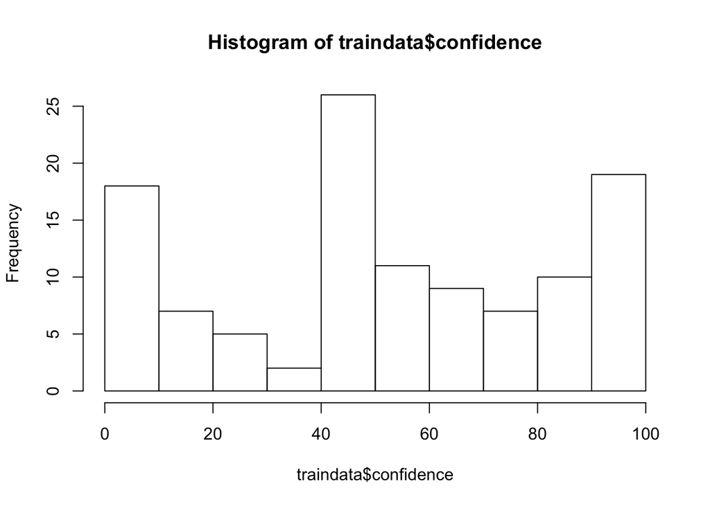

```r
hist(traindata$confidence)
```

This histogram shows that most values fall around the 50% confidence mark, while there appear to be a considerable number of values at the extremes. This suggests that participants were either very confident, not confident at all, or fairly confident about their choices, but more rarely showed intermediate forms of confidence between the three.

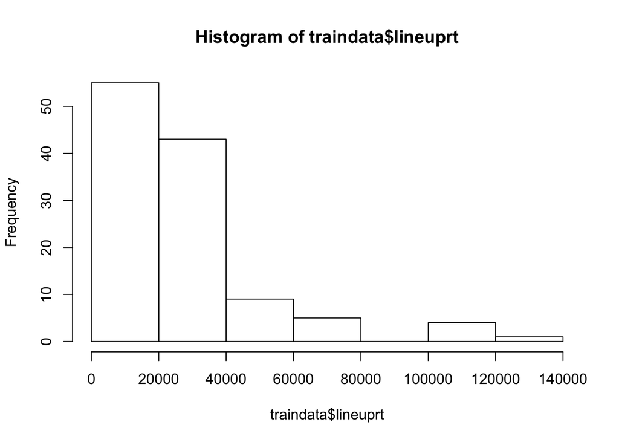

```r
hist(traindata$lineuprt)
```

The reaction time variable appears to show severe positive skew with the great majority of values falling below 40000; there are a number of notable outliers, which reach more than 120 000. This should be kept in mind when we run our analysis.

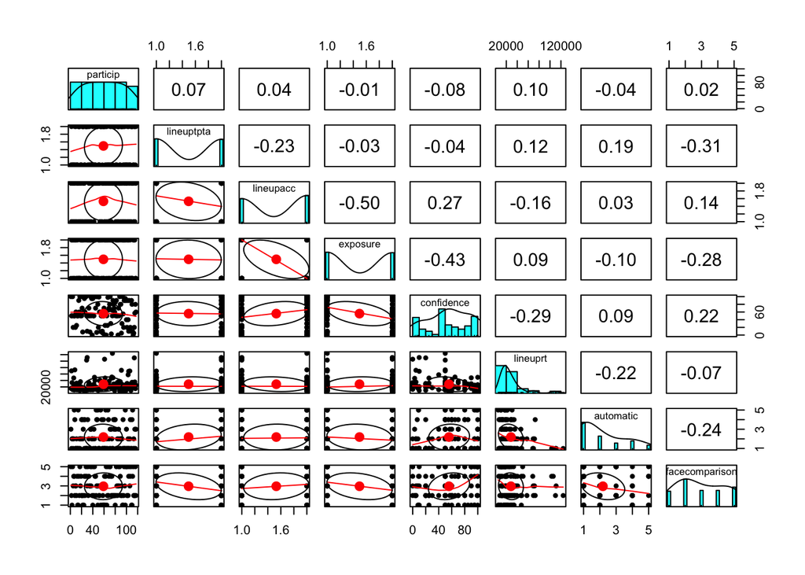

```r
pairs.panels(traindata)
```

Question 4.

1. First we want to create a basline model including control variables for the four different conditions of the study design. We run a logistic regression to account for these effects first and then will compare subsequent models to see whether additional predictors can significantly improve upon it.

```r
control_model <- glm(lineupacc ~ lineuptpta + exposure, family = "binomial", data = traindata)
summary(control_model)
```

```
##
## Call:
## glm(formula = lineupacc ~ lineuptpta + exposure, family = "binomial",
##     data = traindata)
##
## Deviance Residuals:
##     Min       1Q   Median       3Q      Max
## -2.1171  -1.0154   0.4742   0.8958   1.9835
##
## Coefficients:
##               Estimate Std. Error z value Pr(>|z|)
## (Intercept)     2.1286     0.4734   4.496 6.91e-06 ***
## lineuptptatp   -1.4228     0.4854  -2.931  0.00338 **
## exposureshort  -2.5223     0.4863  -5.187 2.14e-07 ***
## ---
## Signif. codes:  0 '***' 0.001 '**' 0.01 '*' 0.05 '.' 0.1 ' ' 1
##
## (Dispersion parameter for binomial family taken to be 1)
##
##     Null deviance: 161.78  on 116  degrees of freedom
## Residual deviance: 120.84  on 114  degrees of freedom
## AIC: 126.84
##
## Number of Fisher Scoring iterations: 4
```

The model above suggests that there are significant differences found in the respective design conditions for line-up accuracy (both for presence of perpetrator and for length of time exposed in line-up). This model will serve as a comparison model once we have constructed a model including our variables of interest. The AIC reported is 126.84. Measures of fit and effect size will need to be compared to this model in order to be meaningfully interpreted.

Experimental Model Construction

2. We next evaluate our other variables of interest in order to evaluate whether adding them significantly improves the overall fit of our model for predicting the identification accuracy. First we consider the interaction between the presence of the perpatrator and (1) the automatic nature of one’s decision and (2) face comparison. Given that this these interactions are to be expected, we have apriori reasons for considering it’s inclusion as the initial step in the model. Both interactions were found to be significant inidividually, therefore they should be accounted for in our model. Next we evaluate whether they are signficant when entered together.

```r
model1 <- glm(lineupacc ~ exposure + lineuptpta*automatic, family = "binomial", data = traindata)
summary(model1)
```

```
##
## Call:
## glm(formula = lineupacc ~ exposure + lineuptpta * automatic,
##     family = "binomial", data = traindata)
##
## Deviance Residuals:
##     Min       1Q   Median       3Q      Max
## -2.1666  -0.5552   0.2538   0.4491   2.6823
##
## Coefficients:
##                        Estimate Std. Error z value Pr(>|z|)
## (Intercept)              4.5919     0.9672   4.747 2.06e-06 ***
## exposureshort           -2.8660     0.6173  -4.643 3.43e-06 ***
## lineuptptatp            -6.2776     1.2572  -4.993 5.94e-07 ***
## automatic               -1.1726     0.3688  -3.179  0.00148 **
## lineuptptatp:automatic   2.1548     0.4912   4.387 1.15e-05 ***
## ---
## Signif. codes:  0 '***' 0.001 '**' 0.01 '*' 0.05 '.' 0.1 ' ' 1
##
## (Dispersion parameter for binomial family taken to be 1)
##
##     Null deviance: 161.777  on 116  degrees of freedom
## Residual deviance:  91.967  on 112  degrees of freedom
## AIC: 101.97
##
## Number of Fisher Scoring iterations: 5
```

```r
model2 <- glm(lineupacc ~ exposure + lineuptpta*facecomparison, family = "binomial", data = traindata)
summary(model2)
```

```
##
## Call:
## glm(formula = lineupacc ~ exposure + lineuptpta * facecomparison,
##     family = "binomial", data = traindata)
##
## Deviance Residuals:
##     Min       1Q   Median       3Q      Max
## -2.1935  -0.6788   0.2276   0.5936   2.6705
##
## Coefficients:
##                             Estimate Std. Error z value Pr(>|z|)
## (Intercept)                   0.3180     1.0645   0.299  0.76516
## exposureshort                -2.7872     0.5896  -4.727 2.28e-06 ***
## lineuptptatp                  3.3054     1.2386   2.669  0.00762 **
## facecomparison                0.6644     0.2920   2.276  0.02288 *
## lineuptptatp:facecomparison  -1.7578     0.4274  -4.113 3.91e-05 ***
## ---
## Signif. codes:  0 '***' 0.001 '**' 0.01 '*' 0.05 '.' 0.1 ' ' 1
##
## (Dispersion parameter for binomial family taken to be 1)
##
##     Null deviance: 161.777  on 116  degrees of freedom
## Residual deviance:  97.513  on 112  degrees of freedom
## AIC: 107.51
##
## Number of Fisher Scoring iterations: 5
```

When considered together, both interaction efects are significant; thus, they will both be included simultaneously in the model.

```r
model3 <- glm(lineupacc ~ exposure + lineuptpta + lineuptpta*automatic + lineuptpta*facecomparison, family = "binomial", data = traindata)
summary(model3)
```

```
##
## Call:
## glm(formula = lineupacc ~ exposure + lineuptpta + lineuptpta *
##     automatic + lineuptpta * facecomparison, family = "binomial",
##     data = traindata)
##
## Deviance Residuals:
##      Min        1Q    Median        3Q       Max
## -2.16581  -0.44746   0.07811   0.35591   2.47272
##
## Coefficients:
##                             Estimate Std. Error z value Pr(>|z|)
## (Intercept)                   2.2863     1.3890   1.646 0.099764 .
## exposureshort                -2.9639     0.7087  -4.182 2.89e-05 ***
## lineuptptatp                 -0.9290     1.7150  -0.542 0.588019
## automatic                    -1.5318     0.4588  -3.339 0.000842 ***
## facecomparison                1.0073     0.4176   2.412 0.015861 *
## lineuptptatp:automatic        2.3764     0.5755   4.129 3.64e-05 ***
## lineuptptatp:facecomparison  -2.0378     0.5470  -3.726 0.000195 ***
## ---
## Signif. codes:  0 '***' 0.001 '**' 0.01 '*' 0.05 '.' 0.1 ' ' 1
##
## (Dispersion parameter for binomial family taken to be 1)
##
##     Null deviance: 161.777  on 116  degrees of freedom
## Residual deviance:  72.018  on 110  degrees of freedom
## AIC: 86.018
##
## Number of Fisher Scoring iterations: 6
```

The inclusion of reaction time doesn’t seem to add anything significant to the model (in fact AIC is bigger than model 3, indicating that we shouldn’t consider it in our model). Thus model3 is our final model and we do not include reaction time.

```r
model4 <-  glm(lineupacc ~ exposure + lineuptpta + lineuptpta*automatic + lineuptpta*facecomparison + lineuprt, family = "binomial", data = traindata)
summary(model4)
```

```
##
## Call:
## glm(formula = lineupacc ~ exposure + lineuptpta + lineuptpta *
##     automatic + lineuptpta * facecomparison + lineuprt, family = "binomial",
##     data = traindata)
##
## Deviance Residuals:
##      Min        1Q    Median        3Q       Max
## -1.88679  -0.38991   0.07157   0.37246   2.54699
##
## Coefficients:
##                               Estimate Std. Error z value Pr(>|z|)
## (Intercept)                  3.075e+00  1.632e+00   1.884 0.059570 .
## exposureshort               -3.028e+00  7.217e-01  -4.195 2.73e-05 ***
## lineuptptatp                -1.150e+00  1.765e+00  -0.651 0.514737
## automatic                   -1.570e+00  4.546e-01  -3.454 0.000552 ***
## facecomparison               9.446e-01  4.191e-01   2.254 0.024221 *
## lineuprt                    -1.706e-05  1.632e-05  -1.045 0.295805
## lineuptptatp:automatic       2.376e+00  5.742e-01   4.139 3.49e-05 ***
## lineuptptatp:facecomparison -1.969e+00  5.429e-01  -3.628 0.000286 ***
## ---
## Signif. codes:  0 '***' 0.001 '**' 0.01 '*' 0.05 '.' 0.1 ' ' 1
##
## (Dispersion parameter for binomial family taken to be 1)
##
##     Null deviance: 161.78  on 116  degrees of freedom
## Residual deviance:  70.95  on 109  degrees of freedom
## AIC: 86.95
##
## Number of Fisher Scoring iterations: 6
```

Next we formally conduct a log-likelihood ratio test beteween our experimental model and control model, to evaluate its usefulness in predicting eyewitness accuracy. The overall comparison test was found to be significant (p <.001), with an overall R-squared change of 0.530, indicating that our experimental model improved the fit of the control model with a large effect size. The calculated AIC for our final model is 86.018, which is considerably lower than our control model (126.84). Given that AIC incoroporates both measures of model fit as well as model simplicity (i.e. models with fewer variables), we can be confident that our added variables are meaningfully improving the model.

```r
nagelkerke(model3, control_model)
```

```
## $Models
##
## Model: "glm, lineupacc ~ exposure + lineuptpta + lineuptpta * automatic + lineuptpta * facecomparison, binomial, traindata"
## Null:  "glm, lineupacc ~ lineuptpta + exposure, binomial, traindata"
##
## $Pseudo.R.squared.for.model.vs.null
##                              Pseudo.R.squared
## McFadden                             0.404001
## Cox and Snell (ML)                   0.341140
## Nagelkerke (Cragg and Uhler)         0.529734
##
## $Likelihood.ratio.test
##  Df.diff LogLik.diff  Chisq    p.value
##       -4     -24.409 48.818 6.3735e-10
##
## $Number.of.observations
##
## Model: 117
## Null:  117
##
## $Messages
## [1] "Note: For models fit with REML, these statistics are based on refitting with ML"
##
## $Warnings
## [1] "None"
```

3. The models considered above suggest a number of predictors are useful in predicting the accuracy of the decision that someone makes during eye-witness testimony. This has implications for how eye-witness testimony is conducted and how reliable someone’s report may be when testifying in court. Firstly, an interaction effect between automatic strategy and the presence/absence of the perpetrator is present.

Some diagnostics using the Dharma package. The scaled residuals do not deviate too far from the red lines and the KS test is not significant, therefore we can assume that the residuals are not having an undue influence on our model results.

```
## DHARMa::plotResiduals - low number of unique predictor values, consider setting asFactor = T
## DHARMa::plotResiduals - low number of unique predictor values, consider setting asFactor = T
```

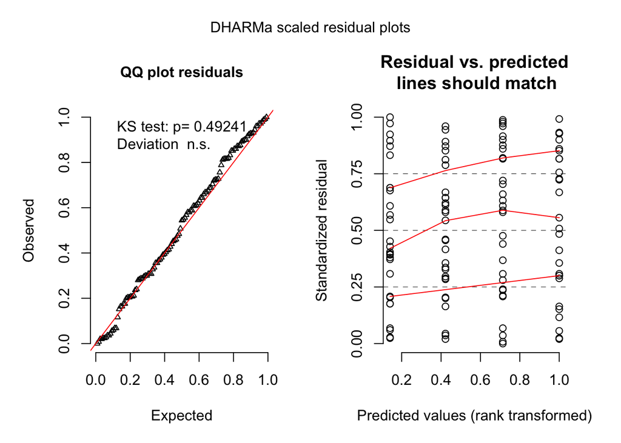

```r
plot(simulateResiduals(control_model))
```

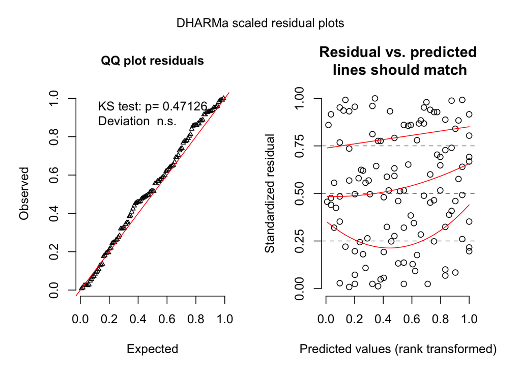

```r
plot(simulateResiduals(model3))
```

Question 5.

First we build the model that we are wanting to apply, considering the presence of the perpetrator and associated confidence.

```r
model_predict <- glm(lineupacc ~ lineuptpta + confidence, family = "binomial", data = traindata)
```

1. Now we construct a new data frame for each of the respective line-up conditions (i.e. perp present or absent) and calculate the respective probabilities for a correct identification under 80% confidence.

```r
newdata1 = data.frame(lineuptpta = "ta", confidence = 80)

pred1 <- predict(model_predict, newdata1, type = "response")
```

When the perpetrator is absent, there is a predicted probability of 0.75 (i.e. 75%) that someone with 80% confidence will correctly determine that the perpetrator is not present in the line-up.

```r
newdata2 = data.frame(lineuptpta = "tp", confidence = 80)

pred2 <- predict(model_predict, newdata2, type = "response")
```

When the perpetrator is present, however, there is a predicted probability of 0.51 (i.e. 51%) that someone with 80% confidence will correctly determine that the perpetrator is present in the line-up. This is not different to chance and thus it suggests that high confidence in a positive detection may not be informative of accurate but that high confidence in a negative detection (saying that the perp is not there) may be informative.

2. Converting from probabilities to odds.

When perpetrator is absent, the odds are roughly 3:1, indicating that this person will on average be correct 3 out of 4 times.

```r
odds1 <- pred1/(1-pred1)
print(odds1)
```

```
##       1
## 3.00015
```

When the perpetrator is present, the odds are roughly 1:1, meaning that a correct or false identification are equally as likely.

```r
odds2 <- pred2/(1-pred2)
print(odds2)
```

```
##        1
## 1.051719
```

3. Calculating the partial odds for the relationship between confidence and the presence or absence of the perpetrator in the line-up.

```r
summary(model_predict)
```

```
##
## Call:
## glm(formula = lineupacc ~ lineuptpta + confidence, family = "binomial",
##     data = traindata)
##
## Deviance Residuals:
##     Min       1Q   Median       3Q      Max
## -1.7920  -1.1070   0.6417   1.0268   1.7839
##
## Coefficients:
##               Estimate Std. Error z value Pr(>|z|)
## (Intercept)  -0.409498   0.451868  -0.906  0.36481
## lineuptptatp -1.048236   0.404820  -2.589  0.00961 **
## confidence    0.018852   0.006694   2.816  0.00486 **
## ---
## Signif. codes:  0 '***' 0.001 '**' 0.01 '*' 0.05 '.' 0.1 ' ' 1
##
## (Dispersion parameter for binomial family taken to be 1)
##
##     Null deviance: 157.72  on 113  degrees of freedom
## Residual deviance: 142.13  on 111  degrees of freedom
##   (3 observations deleted due to missingness)
## AIC: 148.13
##
## Number of Fisher Scoring iterations: 4
```

Calculating the partial odds for both variables.

```r
exp(coefficients(model_predict))
```

```
##  (Intercept) lineuptptatp   confidence
##    0.6639833    0.3505556    1.0190308
```

Thus, the respective partial odds for each variable is 0.35 and 1.02.

2. Create a confusion matrix.

We can assess the accuracy of the above model through looking at a confusion matrix and interpreting the specificity and sensitivity.

Specificity here refers to the fraction of people correctly identifying the perpetrator as absent in the line-up. The value found was 0.65, suggesting that using this model, 65% of absent identifications were correct. While this is not much higher, it seems to do better than chance alone. Thus, it seems that the model is relatively better at correctly identifying when the perpetrator is absent as opposed to correctly identifying that the perpetrator is present. The significance test suggests that our model is not significant (p = 0.055), thus overall our model does not do better in chance in predicting a correct response in lineup accuracy.

```r
predict1 <- predict(model_predict, traindata, type="response")

confusionMatrix(as.factor(as.numeric(predict1 >= .5)),
                as.factor(traindata$lineupacc))
```

```
## Confusion Matrix and Statistics
##
##           Reference
## Prediction  0  1
##          0 30 21
##          1 24 39
##
##                Accuracy : 0.6053
##                  95% CI : (0.5094, 0.6955)
##     No Information Rate : 0.5263
##     P-Value [Acc > NIR] : 0.05493
##
##                   Kappa : 0.2061
##  Mcnemar's Test P-Value : 0.76559
##
##             Sensitivity : 0.5556
##             Specificity : 0.6500
##          Pos Pred Value : 0.5882
##          Neg Pred Value : 0.6190
##              Prevalence : 0.4737
##          Detection Rate : 0.2632
##    Detection Prevalence : 0.4474
##       Balanced Accuracy : 0.6028
##
##        'Positive' Class : 0
##
```